# Deploying Predictive Models in R

September 30, 2015

## Agenda

A short presentation and then a **demo**:

- About Us
- Intro
- The Problem: Operationalizing Predictive Models
- Solutions
- Case Study: Iris Flower Predictor
- Demo
- Q & A

## About Us

- **Daniel Emaasit** (Ph.D. Student)  
  Use R for statistical programming in my research to solve Transportation Engineering problems like crashes, congestion e.t.c.
  - Github: https://github.com/Emaasit
  - Email: daniel.emaasit@gmail.com
  - Website: http://www.danielemaasit.com
- **Steve Wells** (C.T.O, Cumulus)  
  Computer Programmer & Data Scientist
  - Github: https://github.com/yxes
  - Email: yxes@cpan.org
  - Website: http://www.stephendwells.com/

## Intro

Common examples of data products:

- Loan/credit approval
- Recommendation systems (Movies, products, news feed)
- Quoting premiums; claims estimates
- Churn reduction/ Customer retention

## The Problem: Operationalizing Predictive Models (1/2)

[figure not shown]

- Data scientists may not be good at web programming or app dev
- Software enginners may not be good at machine learning

## The Problem: Operationalizing Predictive Models (2/2)

- Different languages are good for different tasks

[figure not shown]

## Solutions

1. Translate code
2. Predictive API Engines
   - [Domino Data Labs](http://dominodatalab.com)
   - [Yhat](https://www.yhathq.com)
   - [PredictionIO](https://prediction.io)
   - [Microsoft AzureML](https://azure.microsoft.com/en-us/services/machine-learning)
   - [BigML](https://bigml.com)
   - [Revolution Analytics DeployR](http://deployr.revolutionanalytics.com)
   - [Sense](https://sense.io)

## Why Use Predictive API Engines

- I do not have time/skills for every single task
- I want to focus on understanding my problem and improving models

## Predictive API Engines, Part 1: Domino Data Lab

[figure not shown]

## How Domino Works

[figure not shown]

- Data scientists focus on developing & improving models
- Software enginners focus on maintaining the apps

## Demo

- 1st: Use random forests to predict the flower species in the iris dataset
- 2nd: Turn the model into a web service
- 3rd: Call the web service in a sample app

```r
library(xtable)
data(iris)
print(xtable(head(iris, 5)), type = "html", include.rownames = F)
```

| Sepal.Length | Sepal.Width | Petal.Length | Petal.Width | Species |
| --- | --- | --- | --- | --- |
| 5.10 | 3.50 | 1.40 | 0.20 | setosa |
| 4.90 | 3.00 | 1.40 | 0.20 | setosa |
| 4.70 | 3.20 | 1.30 | 0.20 | setosa |
| 4.60 | 3.10 | 1.50 | 0.20 | setosa |
| 5.00 | 3.60 | 1.40 | 0.20 | setosa |

## Let's Do it together

- Create a free account on dominodatalab.com
- Fork my project from my account https://app.dominodatalab.com/SparkIQLabs/helloWorld

[figure not shown]

## Simple WebSever Application

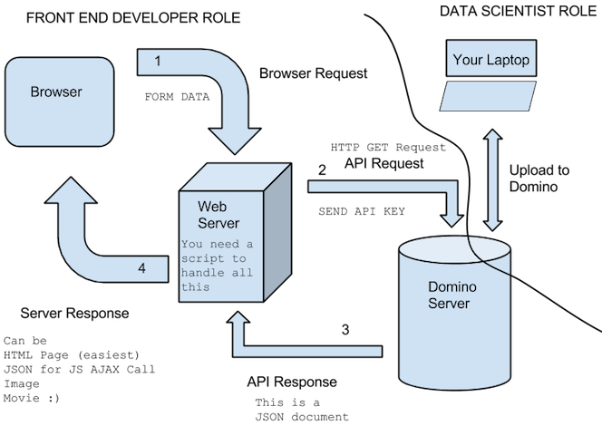

## Action Shot

**Web Sample** http://bit.ly/1YPQFJu

*supplied by heroku*

or run it yourself

**Github** http://github.com/yxes/domino_iris

## Relevant Code (1/2)

### Formulate Request

```python
MODEL_ATTRS = [ 'sepal_length', 'sepal_width',
                'petal_length', 'petal_width' ]

if request.method == 'POST': # you submitted the form

        attributes = [] # just the values from the form in an array
        for field in MODEL_ATTRS:
            attributes.append(request.form[field])
        result = fetch_score(attributes)
        result = result.json()
```

## Relevant Code (2/2)

### API Call

```python
API_KEY = 'KaxzbZ3bu1VNF7yUpQ3TmtUl6reJjp6xjHLoCnPUhsVbrE6nJ9wjGg31FW6cCDcZ'

def fetch_score(attributes):
    return requests.post(
        "https://app.dominodatalab.com/v1/SparkIQLabs/helloWorld/endpoint",
        headers = {
            'X-Domino-Api-Key': API_KEY,
            'Content-type': 'application/json'
        },
        json={ "parameters": attributes }
)
```

## Best Practices for Using a Predictive API Engine

- Separate training, initialization, and prediction
- Make prediction functions thread-safe
- Leverage persistence/serialization tools (e.g. pickle)

## What your Predictive API Engine should have for Production

- Very low latency
- Zero-downtime upgrades
- High availability
- Reproducibility
- Logging
- Security

## Thank you

- **Daniel Emaasit**
  - Github: https://github.com/Emaasit
  - Email: daniel.emaasit@gmail.com
  - Website: http://www.danielemaasit.com
- **Steve Wells**
  - Github: https://github.com/yxes
  - Email: yxes@cpan.org
  - Website: http://www.stephendwells.com/
- **Slides available here**:
  - Github: https://github.com/yxes/domino-iris